# Comment utiliser cette présentation?

## Structure

On peut choisir les thèmes principaux en naviguant à l'horizontal, de gauche à droite.

Une fois un thème principal choisi, on fait défiler les diapositives à la verticale, de haut en bas.

## Clavier

Utilisez les flèches de votre clavier pour naviguer de diapositive en diapositive.

Alternativement, vous pouvez utiliser les boutons en forme de flèches situés dans le coin inférieur droit de la page.

Pour avoir une vue d'ensemble de la présentation, appuyez sur la touche `O` de votre clavier.

# Structures de données

## Structure de quoi?

Un script R décrit, dans un langage spécialisé, une procédure à appliquer à un ensemble de données.

Il faut donc stocker ces données de manière à pouvoir les consulter et éventuellement les modifier facilement. Une «manière de stocker des données» est ce que l'on appelle une *structure de données*.

Différents types de données demandent différentes structures. Voici les principales.

## Vecteur

Tableau en 1 dimension. Est *homogène*, c'est à dire que chacune des entrées est du même type.

```r
1:10
```

1. 1

2. 2

3. 3

4. 4

5. 5

6. 6

7. 7

8. 8

9. 9

10. 10

```r
c("a", "b", "c")
```

1. 'a'

2. 'b'

3. 'c'

```r
c(1, "a")
```

1. '1'

2. 'a'

Dans le dernier exemple, remarquez que le nombre `1` a été transformé en la chaîne de caractère `"1"`.

**Remarque:** Il n'y a pas de scalaire dans R; ceux-ci sont représentés comme des vecteurs de longueur 1.

```r
42
```

42

```r
c(42)
```

42

```r
identical(42, c(42))
```

TRUE

## Matrice

Tableau homogène en 2 dimensions.

```r
matrix(1:(3 * 5), nrow = 3, ncol = 5)
```

A matrix: 3 × 5 of type int

| 1 | 4 | 7 | 10 | 13 |
| --- | --- | --- | --- | --- |
| 2 | 5 | 8 | 11 | 14 |
| 3 | 6 | 9 | 12 | 15 |

```r
matrix(NA, nrow = 2, ncol = 2)
```

A matrix: 2 × 2 of type lgl

| NA | NA |
| --- | --- |
| NA | NA |

Dans le dernier cas, on a rempli une matrice $2 \times 2$ à l'aide d'un vecteur de longueur 1 `NA`. On dit que R a *recyclé* le vecteur.

## Data Frame

Tableau en 2 dimensions. Les colones doivent être *homogènes*. **C'est la structure à utiliser pour stocker les jeux de données**.

```r
data.frame(nombres = c(1, 2, 3), lettres = c("a", "b", "c"))
```

A data.frame: 3 × 2

| nombres <dbl> | lettres <chr> |
| --- | --- |
| 1 | a |
| 2 | b |
| 3 | c |

```r
head(iris)
```

A data.frame: 6 × 5

|  | Sepal.Length <dbl> | Sepal.Width <dbl> | Petal.Length <dbl> | Petal.Width <dbl> | Species <fct> |
| --- | --- | --- | --- | --- | --- |
| 1 | 5.1 | 3.5 | 1.4 | 0.2 | setosa |
| 2 | 4.9 | 3.0 | 1.4 | 0.2 | setosa |
| 3 | 4.7 | 3.2 | 1.3 | 0.2 | setosa |
| 4 | 4.6 | 3.1 | 1.5 | 0.2 | setosa |
| 5 | 5.0 | 3.6 | 1.4 | 0.2 | setosa |
| 6 | 5.4 | 3.9 | 1.7 | 0.4 | setosa |

On peut accéder à variable d'un `data.frame` en donnant son nom.

```r
head(iris$Sepal.Length)
```

1. 5.1

2. 4.9

3. 4.7

4. 4.6

5. 5

6. 5.4

```r
head(iris[["Sepal.Length"]])
```

1. 5.1

2. 4.9

3. 4.7

4. 4.6

5. 5

6. 5.4

Alternativement, on peut donner le numéro de la ligne ou de la colonne qui nous intéresse.

```r
iris[1,]
```

A data.frame: 1 × 5

|  | Sepal.Length <dbl> | Sepal.Width <dbl> | Petal.Length <dbl> | Petal.Width <dbl> | Species <fct> |
| --- | --- | --- | --- | --- | --- |
| 1 | 5.1 | 3.5 | 1.4 | 0.2 | setosa |

```r
head(iris[,1])
```

1. 5.1

2. 4.9

3. 4.7

4. 4.6

5. 5

6. 5.4

```r
iris[1, 3]
```

1.4

Il est possible d'accéder à plusieurs lignes ou plusieurs colonnes en même temps. On procède de la même manière , mais en utilisant des vecteurs de longueur supérieure à 1.

```r
head(iris[,2:3])
```

A data.frame: 6 × 2

|  | Sepal.Width <dbl> | Petal.Length <dbl> |
| --- | --- | --- |
| 1 | 3.5 | 1.4 |
| 2 | 3.0 | 1.4 |
| 3 | 3.2 | 1.3 |
| 4 | 3.1 | 1.5 |
| 5 | 3.6 | 1.4 |
| 6 | 3.9 | 1.7 |

```r
iris[c(1, 4, 5), 2:3]
```

A data.frame: 3 × 2

|  | Sepal.Width <dbl> | Petal.Length <dbl> |
| --- | --- | --- |
| 1 | 3.5 | 1.4 |
| 4 | 3.1 | 1.5 |
| 5 | 3.6 | 1.4 |

## Autres structures

R est distribué avec d'autres structures, par exemple:

- list (*scoop*: les `data.frame` sont en fait des listes, pas des tableaux!)
- array (tableaux homogènes en $d$ dimensions, les matrices sont le cas particulier $d = 2$).

Pour le cours, la structure la plus importante est le `data.frame`.

# Variables

## Qu'est-ce c'est?

Il est pratique d'enregistrer certaines données en mémoire et de leur donner un nom pour y référer. Pour ce faire, il suffit d'assigner une valeur à une variable.

```r
x <- 42
x
```

42

```r
monVec <- 1:10
monVec
```

1. 1

2. 2

3. 3

4. 4

5. 5

6. 6

7. 7

8. 8

9. 9

10. 10

```r
df_iris34 <- iris[34:37,2:3]
df_iris34
```

A data.frame: 4 × 2

|  | Sepal.Width <dbl> | Petal.Length <dbl> |
| --- | --- | --- |
| 34 | 4.2 | 1.4 |
| 35 | 3.1 | 1.5 |
| 36 | 3.2 | 1.2 |
| 37 | 3.5 | 1.3 |

## Règles

Le nom d'une variable *ne peut pas* contenir d'espace.

Le nom d'une variable *peut* contenir des chiffres.

Toutefois, le nom d'une variable *ne peut pas* commencer par un chiffre.

## Règles de style

Utiliser des lettres minuscules.

Différencier les mots à l'aide de majuscules (`camelCase`) ou de barres de soulignement (`snake_case`).

Utilisez des noms *courts* mais *significatifs*. Donner priorité au second sur le premier.

# Fonctions

## Qu'est-ce que c'est?

Nous savons maintenant comment stocker des données. Les fonctions permettent d'opérer sur celles-ci.

Les fonctions sont faciles à reconaître car leur nom est suivit de parenthèses `()`.

Les fonctions correspondent grosso modo à des actions. Par exemple

- *Calcule* la moyenne: `mean()`.
- *Calcule* l'écart-type: `sd()`.
- *Dessine* un diagramme en boîte à moustaches: `boxplot()`.

## Arguments

Souvent, il faut fournir des précisions aux fonctions concernant la tâche que l'on souhaite accomplir. Pour ce faire, il suffit de leur passer des *arguments*. Ceux-ci prennent la forme d'objets séparés par des virgules que l'on écrit à l'intérieur des parenthèses suivant la fonction d'intérêt. Par exemple

Calcule la moyenne *des nombres de 1 à 10*:

```r
mean(1:10)
```

5.5

Calcule l'écart-type *de ce vecteur*:

```r
vec <- c(4, 2, 9)
sd(vec)
```

3.60555127546399

Dessine un diagramme en bôite à moustaches *de ces données* se trouvant dans *ce `data.frame`* en les divisant selon *ces niveaux*:

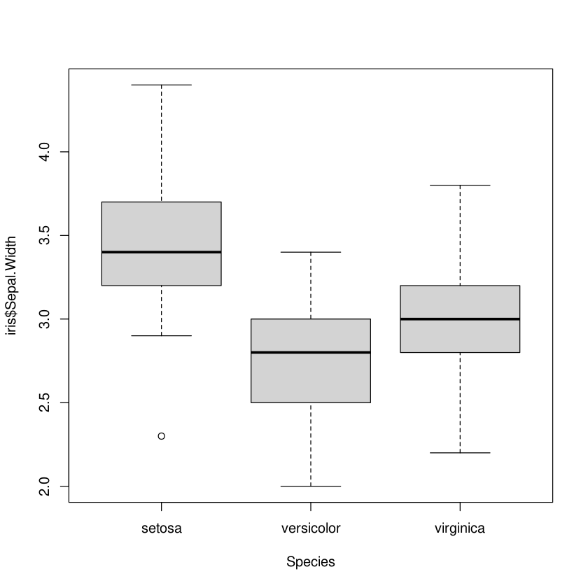

```r
boxplot(Sepal.Width ~ Species, iris)
```

## Documentation

On peut trouver des détails sur les arguments accepté par une fonction en consultant la documentation.

```r
? mean
```

| mean {base} | R Documentation |
| --- | --- |

Arithmetic Mean

Description

Generic function for the (trimmed) arithmetic mean.

Usage

```
mean(x, ...)

## Default S3 method:
mean(x, trim = 0, na.rm = FALSE, ...)
```

Arguments

| `x` | An **R** object. Currently there are methods for numeric/logical vectors and date, date-time and time interval objects. Complex vectors are allowed for `trim = 0`, only. |
| --- | --- |
| `trim` | the fraction (0 to 0.5) of observations to be trimmed from each end of `x` before the mean is computed. Values of trim outside that range are taken as the nearest endpoint. |
| `na.rm` | a logical value indicating whether `NA` values should be stripped before the computation proceeds. |
| `...` | further arguments passed to or from other methods. |

Value

If `trim` is zero (the default), the arithmetic mean of the values in `x` is computed, as a numeric or complex vector of length one. If `x` is not logical (coerced to numeric), numeric (including integer) or complex, `NA_real_` is returned, with a warning.

If `trim` is non-zero, a symmetrically trimmed mean is computed with a fraction of `trim` observations deleted from each end before the mean is computed.

References

Becker, R. A., Chambers, J. M. and Wilks, A. R. (1988) *The New S Language*. Wadsworth & Brooks/Cole.

See Also

`weighted.mean`, `mean.POSIXct`, `colMeans` for row and column means.

Examples

```
x <- c(0:10, 50)
xm <- mean(x)
c(xm, mean(x, trim = 0.10))
```

[Package *base* version 4.0.2 ]

Dans la documentation, les arguments suivi d'un `=` possèdent une valeur par défaut; *il n'est pas obligatoire de leur passer une valeur lorsqu'on appelle la fonction*.

Par contre, il est obligatoire de passer une valeur pour chacun des arguments ne possédant pas de valeur par défaut.

Pour simplifier les choses, il est possible de passer une valeur à un argument précis en le nommant.

```r
mean(c(1, 2, NA, 3), na.rm = TRUE)
```

2

# Exercices

## Exercice 1

Écrivez un script qui

- affiche les nombres de 20 à 50,
- calcule la moyenne des nombres de 20 à 60 et
- calcule la somme des nombres de 51 à 91.

**Indice**: Consultez la documentation de la fonction `sum`.

## Exercice 2

En utilisant les données fournies dans le jeu de données `iris`, faites un graphique en boîtes à moustaches de la longueur des pétales en fonction de l'espèce. Ajouter un titre et des étiquettes appropriées pour les axes des $x$ et $y$.

**Indice**: regardez la documentation de la fonction `boxplot`.

## Exercice 3

Écrivez un script qui génère un vecteur aléatoire de longueur 15 dont les entrées sont comprises entre -50 et 50.

**Indice**: Consultez la documentation de la fonction `sample`.

## Exercice 4

Écrivez un script qui demande des informations à l'utilisateur et les affiche à l'écran.

**Indice**: regardez la documentation des fonctions `readline` et `print`.